# Hesse

```python
import matplotlib.pyplot as plt
%matplotlib inline
import re, nltk, logging, glob
import nltk
from nltk.corpus import stopwords
from nltk.stem.cistem import Cistem
from gensim.models import Word2Vec, Phrases
import seaborn as sns
import numpy as np

#Set global plotting params.
sns.set_style('darkgrid',
             rc={'axes.facecolor': '.9',
                 'grid.color': '.8'})
sns.set_palette('muted')
sns_c = sns.color_palette(palette='muted')
```

```python
plt.rcParams['figure.figsize'] = 10, 6
```

```python
# Load Hesse books.
# Printing words in all caps to get a feeling for headlines and
# chapter numeration.

book_list = []
pattern = re.compile('[A-ZÄÖÜß]{2,}')
for entry in glob.glob('./hesse/*txt'):
    with open(entry, 'r') as fileHandle:
        book = fileHandle.read()
        chars = set(book)
        print(f'# of characters in book file: {len(chars)}')

    book_split = book.split()[160:-3400] # Rid introduction and headline words.
    book = ' '.join(book_split)
    print(pattern.findall(book))
    book_list.append(book)
```

```
# of characters in book file: 95
['Eß', 'Iß']
# of characters in book file: 96
[]
# of characters in book file: 102
['VIII', 'IX', 'DIE', 'DICHTUNG', 'EINE', 'SAMMLUNG', 'VON', 'MONOGRAPHIEEN', 'HERAUSGEGEBEN', 'VON', 'PAUL', 'REMER', 'BUCHSCHMUCK', 'VON', 'HEINRICH', 'VOGELER', 'FÜR', 'BÜCHERLIEBHABER', 'WURDEN', 'DIE', 'ERSTEN', 'ZWANZIG', 'EXEMPLARE', 'DIESES', 'BUCHES', 'AUF', 'ECHTES', 'BÜTTENPAPIER', 'GEDRU…
# of characters in book file: 94
[]
# of characters in book file: 97
['Eß', 'Eß', 'Eß', 'II', 'III', 'IV']
# of characters in book file: 95
[]
# of characters in book file: 95
['II', 'III', 'Eß', 'IV', 'VI', 'VII', 'VIII']
# of characters in book file: 91
['BEI', 'DEN', 'SAMANAS', 'GOTAMA', 'ERWACHEN', 'ZWEITER', 'TEIL', 'KAMALA', 'BEI', 'DEN', 'KINDERMENSCHEN', 'SANSARA', 'AM', 'FLUSSE', 'OM', 'DER', 'FÄHRMANN', 'DER', 'SOHN', 'OM', 'GOVINDA']
```

```python
# Loading Thomas Mann books.

mann_book_list = []
pattern = re.compile('[A-ZÄÖÜß]{2,}')
for entry in glob.glob('./mann/*.txt'):
    with open(entry, 'r', encoding='latin_1') as fileHandle:
        book = fileHandle.read()
        chars = set(book)
        print(f'# of characters in book file: {len(chars)}')

    book_split = book.split()[160:-3400] # Rid introduction and headline words.
    book = ' '.join(book_split)
    print(pattern.findall(book)) # Find proportion in capital headlines etc. Just to get a feel for it.
    mann_book_list.append(book)
```

```
# of characters in book file: 105
['THOMAS', 'MANN', 'MIT', 'EINER', 'VORREDE', 'VON', 'HANNS', 'MARTIN', 'ELSTER', 'II', 'III', 'III', 'III', 'III', 'III', 'III', 'II', 'XV', 'II', 'II', 'II', 'II', 'II', 'II', 'SW', 'SW', 'III', 'III']
# of characters in book file: 105
['MONSIEUR', 'FRAN', 'OIS', 'KNAAK', 'NACH', 'DAENEMARK', 'FINIS']
# of characters in book file: 97
['Eß']
# of characters in book file: 108
['BUCH', 'GEMEINSCHAFT', 'GMBH', 'Eß', 'Eß', 'Eß', 'Eß', 'Eß', 'Eß', 'Iß', 'Iß', 'Eß', 'Eß', 'PS', 'Eß', 'Eß', 'Eß', 'Eß', 'AG', 'Eß', 'Eß', 'Eß', 'Eß', 'Eß', 'III', 'Eß', 'Eß', 'Eß', 'Eß', 'Eß', 'Eß', 'Eß', 'Eß', 'Eß', 'Eß', 'Eß', 'Eß', 'Eß', 'Eß', 'Eß', 'Eß', 'Eß', 'Eß', 'Eß', 'Eß', 'Eß', 'SO', 'S…
# of characters in book file: 97
['SCHWERE', 'STUNDE']
# of characters in book file: 97
[]
# of characters in book file: 106
['COLLECTION', 'FISCHER', 'THOMAS', 'MANN', 'BERLIN', 'INHALT', 'II', 'III', 'IV', 'VI', 'VII', 'VIII', 'IX', 'XI', 'XII', 'XIII', 'XIV', 'XV', 'ABC', 'ABC', 'II', 'III', 'IV', 'VI', 'VII', 'VIII', 'IX', 'XI', 'XII', 'XIII', 'XIV', 'II', 'III', 'FISCHER', 'VERLAG', 'BERLIN']
```

```python
def string_to_wordlist(raw_review, remove_stopwords=False, lemmatize=False):

    #remove punctuation.
    letters_only = re.sub('[^a-zA-ZäöüÄÖÜß]', ' ', raw_review)

    #lower case and split.
    words = letters_only.lower().split()

    #remove stopwords if wanted.
    if remove_stopwords:
        stops = set(stopwords.words("german"))
        words = [w for w in words if not w in stops]

    #lemmatize words for better model quality.
    if lemmatize:
        lemmatizer = Cistem()
        words = [lemmatizer.segment(word)[0] for word in words]

    return words
```

```python
tokenizer = nltk.data.load("tokenizers/punkt/german.pickle")

def string_to_sentence(review, remove_stopwords=False, lemmatize=False):

    #review to sentence
    raw_sentences = tokenizer.tokenize(review.strip())

    #loop over sentences
    sentences= []
    for raw_sentence in raw_sentences:
        if len(raw_sentence)>0:
            sentences.append(string_to_wordlist(raw_sentence, lemmatize, remove_stopwords))

    return sentences
```

## Tokenize and Tag

Tagger from: https://datascience.blog.wzb.eu/2016/07/13/accurate-part-of-speech-tagging-of-german-texts-with-nltk/

```python
import pickle
import pandas as pd
with open('./nltk_german_classifier_data.pickle', 'rb') as f:
    tagger = pickle.load(f)
```

```python
# Tag after removing punctuation.
tag_test = tagger.tag(
    re.sub('[^a-zA-ZäöüÄÖÜß]', ' ', book_list[0]).split()
    )
```

```python
df = pd.DataFrame(list(zip(*tag_test))).T
df.columns = ['words', 'tags']
```

```python
# Source for tag meanings:
# https://www.linguistik.hu-berlin.de/de/institut/professuren/korpuslinguistik/ \
# mitarbeiter-innen/hagen/STTS_Tagset_Tiger
tag_from_www = 'ADJA  ADJD  ADV  APPR  APPRART APPO  APZR ART  CARD' \
    ' FM ITJ KOUI KOUS KON KOKOM NN NE PDAT PDS PIAT PIS PPER' \
    ' PPOSAT PPOSS PRELS PRELAT PRF PWS PWAT PWAV PROAV PTKZU' \
    ' PTKNEG PTKVZ PTKANT PTKA TRUNC VVFIN VAFIN VMFIN VVINF VAINF' \
    ' VMINF VVIMP VAIMP VVPP VAPP VMPP VVIZU XY $, $( $. ' \
    .split()
```

```python
# Aggregate tags into more general grammatical concepts.

rename_mask = {
    'ADJA':'adjective','ADJD':'adjective',
    'ADV':'adverb',
    'APPR':'praep','APPRART':'praep','APPO':'praep','APZR':'praep',
    'ART':'article',
    'NN':'nomen',
    'NE':'name',
    'NNE':'nomen',
    'ITJ':'ITJ',
    'TRUNC':'TRUNC',
    'XY':'XY',
    'CARD':'zahl',
    'FM':'flanguage',
    '$,':'$,',
    '$(':'$(',
    '$.':'$.',
    'KOUI':'konjunktion','KOUS':'konjunktion','KON':'konjunktion','KOKOM':'konjunktion',
    'PDAT':'pron','PDS':'pron','PIAT':'pron','PIS':'pron',
    'PPER':'pron','PPOSAT':'pron','PPOSS':'pron','PRELS':'pron',
    'PRELAT':'pron','PRF':'pron','PWS':'pron','PWAT':'pron','PWAV':'pron', 'PROAV':'pron',
    'PTKZU':'partikel','PTKNEG':'partikel','PTKVZ':'partikel','PTKANT':'partikel','PTKA':'partikel',
    'VVFIN':'verb','VAFIN':'verb','VMFIN':'verb','VVINF':'verb','VAINF':'verb','VMINF':'verb','VVIMP':'verb',
    'VAIMP':'verb','VVPP':'verb','VAPP':'verb','VMPP':'verb','VVIZU':'verb'
}
```

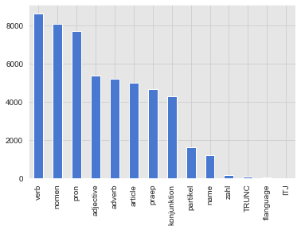

```python
df = df.assign(tag_agg = df.tags.map(rename_mask))
df.tag_agg.value_counts().plot(kind='bar')
```

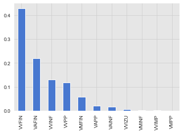

```python
(df.loc[df.tag_agg == 'verb'].tags.value_counts()/ \
    len(df.loc[df.tag_agg == 'verb'])) \
    .plot(kind='bar')
```

how many adverbs per verb?

```python
print('Adverbs per verb:',round(df.tag_agg.value_counts()['adverb']/ \
            df.tag_agg.value_counts()['verb'],
            2))
print('Adjectives per noun:',round(df.tag_agg.value_counts()['adjective']/ \
            df.tag_agg.value_counts()['nomen'],
            2))
```

```
Adverbs per verb: 0.6
Adjectives per noun: 0.67
```

```python
%%time

# Tag all Hesse books.
book_names = [name[:-4].strip('./hesse ').lower() for name in glob.glob('./hesse/*txt')]
hesse_tag_df = pd.DataFrame([], columns=['words','tags','book'])
for name, book in zip(book_names, book_list):

    print(f'Tagging {name}...')
    t = tagger.tag(re.sub('[^a-zA-ZäöüÄÖÜß]', ' ', book).split())

    frame = pd.DataFrame(list(zip(*t))).T
    frame.columns = ['words','tags']
    frame = frame.assign(book=name)

    hesse_tag_df = hesse_tag_df.append(frame)

hesse_tag_df = hesse_tag_df.assign(tag_agg = hesse_tag_df.tags.map(rename_mask))
hesse_tag_df.reset_index(drop=True,inplace=True)
```

```
Tagging nachbarn...
Tagging demian...
Tagging boccaccio...
Tagging gertrud...
Tagging klingsor...
Tagging untermrad...
Tagging camenzind...
Tagging iddharta...
CPU times: user 10min 10s, sys: 5.61 s, total: 10min 15s
Wall time: 11min 2s
```

```python
%%time

# Tag all Mann books.
mann_book_names = [name[:-4].strip('./mann/ ').lower() for name in glob.glob('./mann/*txt')]
mann_tag_df = pd.DataFrame([], columns=['words','tags','book'])
for name, book in zip(mann_book_names, mann_book_list):
    print(f'Tagging {name}...')
    t = tagger.tag(re.sub('[^a-zA-ZäöüÄÖÜß]', ' ', book).split())
    frame = pd.DataFrame(list(zip(*t))).T
    frame.columns = ['words','tags']
    frame = frame.assign(book=name)
    mann_tag_df = mann_tag_df.append(frame)

mann_tag_df = mann_tag_df.assign(tag_agg = mann_tag_df.tags.map(rename_mask))
mann_tag_df.reset_index(drop=True,inplace=True)
```

```
Tagging hoheit...
Tagging tonio...
Tagging tod-venedig...
Tagging buddenbrooks...
Tagging gladius-dei...
Tagging trist...
Tagging friede...
CPU times: user 13min 17s, sys: 7.77 s, total: 13min 25s
Wall time: 14min 36s
```

```python
# Word count per book.
hesse_tag_df.groupby(['book']).words.count() \
    .append(mann_tag_df.groupby(['book']).words.count()) \
    .sort_values(ascending=False)
```

```
book
buddenbrooks    229722
hoheit          117844
gertrud          55125
klingsor         54182
nachbarn         52015
untermrad        48884
demian           46667
camenzind        44890
friede           34295
iddharta         33930
tod-venedig      24793
tonio            23607
trist            14645
boccaccio        10250
gladius-dei       8437
Name: words, dtype: int64
```

```python
print('Avg. Book Length Hesse:')
print(hesse_tag_df.groupby(['book']).words.count().mean())
print('Avg. Book Length Mann:')
print(mann_tag_df.groupby(['book']).words.count().mean())
```

```
Avg. Book Length Hesse:
43242.875
Avg. Book Length Mann:
64763.28571428572
```

### Rolling sum over grammar count

```python
def plot_grammar(document, struk, window_size):

    gram_s = pd.Series(np.where(document.tag_agg.values == struk,1,0))
    gram_s.rolling(window_size, min_periods=1, center=True).sum().plot(kind='line')
    plt.title(struk)
```

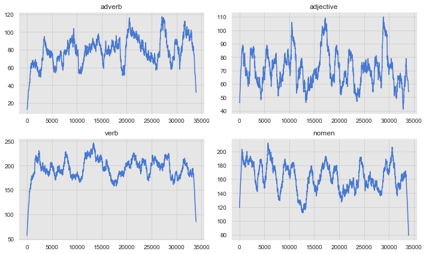

```python
# Plot for Hesse.
f,ax = plt.subplots(2,2,figsize=(10,6))
for i, j in enumerate(['adverb','adjective','verb','nomen']):
    plt.subplot(221+i)
    plot_grammar(hesse_tag_df.loc[hesse_tag_df.book == 'iddharta'], j, 1000)

plt.tight_layout()
```

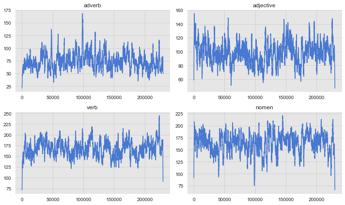

```python
# Plot Mann.

f,ax = plt.subplots(2,2,figsize=(10,6))
for i, j in enumerate(['adverb','adjective','verb','nomen']):
    plt.subplot(221+i)
    plot_grammar(mann_tag_df.loc[mann_tag_df.book == 'buddenbrooks'],j,1000)

plt.tight_layout()
```

```python
# Func to collect the grammar window count for a grammatic structure.
# Returns a Series that can later be collected in a DF.
def grammar_window(document, struk):
    return pd.Series(np.where(document.tag_agg.values == struk,1,0)) \
               .rolling(500, min_periods=500, center=True).sum()
```

```python
# Create a shelf DF, to collect the Series into.
shelf = pd.DataFrame(columns=mann_tag_df.loc[mann_tag_df.book == 'friede'] \
                     .tag_agg.value_counts().index.values)
```

```python
# Populate the shelf frame.
for gram in shelf.columns:
    shelf.loc[:,gram] = grammar_window(mann_tag_df.loc[mann_tag_df.book == 'friede'], gram)
```

```python
shelf = shelf.cumsum(axis=1) # Sort by grammar frequ.
```

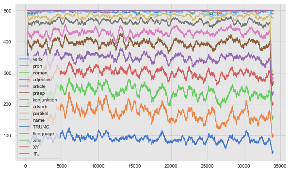

```python
f, ax = plt.subplots(figsize=(10,6))
shelf.loc[:,shelf.columns].plot(kind='line',ax=ax)
```

```python
# Save to disk and make chart with Processing.
path = '/.../Documents/Processing/books/stacked_line/data/mannGrammar.csv'
#shelf.to_csv(path)
```

### Adverb / verb ratio

```python
hesse_tag_df.loc[hesse_tag_df.tag_agg=='adverb'].shape[0]/ \
    hesse_tag_df.loc[hesse_tag_df.tag_agg=='verb'].shape[0]
```

```
0.5091456853884226
```

```python
mann_tag_df.loc[mann_tag_df.tag_agg=='adverb'].shape[0]/ \
    mann_tag_df.loc[mann_tag_df.tag_agg=='verb'].shape[0]
```

```
0.41725004834654805
```

### Adj./Noun ratio

```python
hesse_tag_df.loc[hesse_tag_df.tag_agg=='adjective'].shape[0]/ \
    hesse_tag_df.loc[hesse_tag_df.tag_agg=='nomen'].shape[0]
```

```
0.6215317545350427
```

```python
mann_tag_df.loc[mann_tag_df.tag_agg=='adjective'].shape[0]/ \
    mann_tag_df.loc[mann_tag_df.tag_agg=='nomen'].shape[0]
```

```
0.6939642836700819
```

### Wiki vocab comparison

```python
with open('/.../Desktop/wiki_vocab.txt', 'r',encoding='utf-8',
          newline='\n') as fileHandle:
    wiki_vocab = fileHandle.readlines()
```

```python
words = []
counts = []
for line in wiki_vocab:
    splitLines = line.split()
    word = eval(splitLines[0]).decode('utf-8')
    count= splitLines[1]
    words.append(word)
    counts.append(count)

count_dict = dict(zip(words, map(int,counts)))
wiki_vocab = set(words)
```

```python
print(f'Percentage of Hesses vocab not in wiki vocab:')
print(len(hesse_tag_df.words.loc[~hesse_tag_df.words.apply(lambda x: x.lower()) \
                                 .isin(wiki_vocab)].unique())/ \
    len(hesse_tag_df.words.unique()) * 100, '%')
```

```
Percentage of Hesses vocab not in wiki vocab:
22.04756022235948 %
```

```python
print(f'Percentage of Manns vocab not in wiki vocab:')
print(len(mann_tag_df.words.loc[~mann_tag_df.words.apply(lambda x: x.lower()) \
                                .isin(wiki_vocab)].unique())/ \
    len(mann_tag_df.words.unique()) * 100, '%')
```

```
Percentage of Manns vocab not in wiki vocab:
29.099822772573482 %
```

### Wortschätze

```python
hesse_vocab = set(hesse_tag_df.words.values)
mann_vocab = set(mann_tag_df.words.values)

print(f'Hesse Wortschatz: {len(hesse_vocab)}')
print(f'Hesse relativer Wortschatz: {len(hesse_vocab)/len(hesse_tag_df)*100}%')
print('\n')
print(f'Mann Wortschatz: {len(mann_vocab)}')
print(f'Mann relativer Wortschatz: {len(mann_vocab)/len(mann_tag_df)*100}%')
```

```
Hesse Wortschatz: 32380
Hesse relativer Wortschatz: 9.359923455598176%


Mann Wortschatz: 43447
Mann relativer Wortschatz: 9.583692700670353%
```

```python
print(f'Intersecting vocab: {len(hesse_vocab.intersection(mann_vocab))}')
print(f'Symmetric difference: {len(hesse_vocab.symmetric_difference(mann_vocab))}')
```

```
Intersecting vocab: 14900
Symmetric difference: 46027
```

### Meist genutzte Wörter

```python
print('HESSE:')
print(hesse_tag_df.words.value_counts()[:10]/len(hesse_tag_df)) # Hesse words frequ.
print('Ration of all words:')
print((hesse_tag_df.words.value_counts()[:10]/len(hesse_tag_df)).sum())
print('\nMANN:')
print(mann_tag_df.words.value_counts()[:10]/len(mann_tag_df))  # Mann words frequ.
print('Ration of all words:')
print((mann_tag_df.words.value_counts()[:10]/len(mann_tag_df)).sum())
```

```
HESSE:
und      0.049534
die      0.017523
der      0.017396
ich      0.014890
er       0.014456
zu       0.013193
in       0.013083
war      0.012395
den      0.010016
nicht    0.009987
Name: words, dtype: float64
Ration of all words:
0.17247349996964817

MANN:
und     0.039359
die     0.022319
der     0.020113
in      0.013751
zu      0.013484
er      0.013237
mit     0.012569
den     0.011084
sich    0.010875
das     0.009534
Name: words, dtype: float64
Ration of all words:
0.16632439455335143
```

```python
#Meist genutzt nomen
hesse_tag_df.words \
    .loc[hesse_tag_df.tag_agg == 'nomen'] \
    .value_counts()[:10]
```

```
Leben       556
Vater       397
Zeit        390
Welt        370
Augen       343
Gesicht     338
Mutter      336
Menschen    284
Hand        279
Frau        256
Name: words, dtype: int64
```

```python
#Meist genutzte nomen.
mann_tag_df.words \
    .loc[mann_tag_df.tag_agg == 'nomen'] \
    .value_counts()[:10]
```

```
Herr       1057
Augen       785
Hand        576
Frau        517
Herrn       432
Zeit        402
Leben       369
Gott        366
Kopf        354
Gesicht     331
Name: words, dtype: int64
```

```python
#Definite article ratios HESSE.
hesse_tag_df.words \
    .loc[(hesse_tag_df.tag_agg == 'article') & \
         (hesse_tag_df.words.isin({'der','die','das'}))] \
    .value_counts()
```

```
die    6039
der    6014
das    3303
Name: words, dtype: int64
```

```python
#Definite article ratios MANN.
mann_tag_df.words \
    .loc[(mann_tag_df.tag_agg == 'article') & \
         (mann_tag_df.words.isin({'der','die','das'}))] \
    .value_counts()
```

```
die    9998
der    9094
das    4144
Name: words, dtype: int64
```

```python
%%time
#CUMSUM of new vocab in Buddenbrooks.
vocabulary = set()
cums = []
counter = 0
for w in mann_tag_df.loc[mann_tag_df.book=='buddenbrooks','words']:
    if w not in vocabulary:
        vocabulary.add(w)
        counter += 1
    else:
        pass

    cums.append(counter)
```

```
CPU times: user 181 ms, sys: 76.7 ms, total: 257 ms
Wall time: 332 ms
```

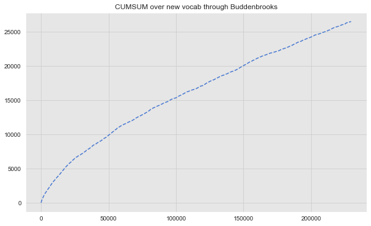

```python
f,ax = plt.subplots()
plt.plot(cums,"--")
plt.title("CUMSUM over new vocab through Buddenbrooks")
```

[output not shown]

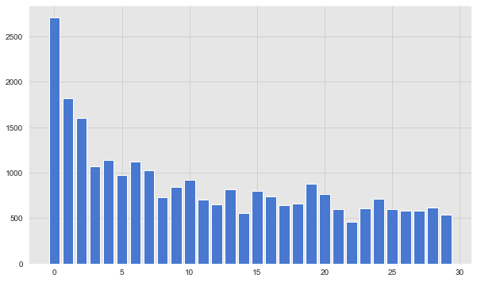

```python
#New vocab bins.
bins = 30
idc = [int(f/bins*len(cums)) for f in range(1,bins)]
vals = pd.Series(cums).loc[idc].values
incr = [vals[i]-vals[i-1] for i in range(1,len(vals))]
incr.insert(0,vals[0])
incr.append(len(vocabulary)-sum(incr))

plt.bar(range(len(incr)), incr)
```

.

### Satzlänge

```python
%%time
hesse_sentences = []
mann_sentences = []

# Parse Hesse.
for i,book in enumerate(book_list):
    print(f'Processed: {i+1}/{len(book_list)}')
    hesse_sentences += string_to_sentence(book)

# Parse Mann.
for i,mbook in enumerate(mann_book_list):
    print(f'Processed: {i+1}/{len(mann_book_list)}')
    mann_sentences += string_to_sentence(mbook)
```

```
Processed: 1/8
Processed: 2/8
Processed: 3/8
Processed: 4/8
Processed: 5/8
Processed: 6/8
Processed: 7/8
Processed: 8/8
Processed: 1/7
Processed: 2/7
Processed: 3/7
Processed: 4/7
Processed: 5/7
Processed: 6/7
Processed: 7/7
CPU times: user 4.22 s, sys: 135 ms, total: 4.35 s
Wall time: 4.9 s
```

```python
print('Mean sentence length Hesse:',
    sum([len(sent) for sent in hesse_sentences if len(sent) != 0])/
    len(hesse_sentences)
     )
print('Longest sentence Hesse:',
     max([len(sent) for sent in hesse_sentences]))
print('Mean sentence length Mann:',
     sum([len(sent) for sent in mann_sentences if len(sent) != 0])/
      len(mann_sentences)
     )
print('Longest sentence Mann:',
     max([len(sent) for sent in mann_sentences]))
```

```
Mean sentence length Hesse: 19.908096909708235
Longest sentence Hesse: 136
Mean sentence length Mann: 24.021990250105976
Longest sentence Mann: 190
```

```python
# Most frequent sentence beginnings.
firsts = []
for sent in hesse_sentences:
    try:
        firsts.append(sent[0])
    except:
        pass
print("Hesse:",pd.Series(firsts).value_counts().index[0])

firsts = []
for sent in mann_sentences:
    try:
        firsts.append(sent[0])
    except:
        pass
print("Mann:",pd.Series(firsts).value_counts().index[0])
```

```
Hesse: ich
Mann: er
```

### Parts of Speech

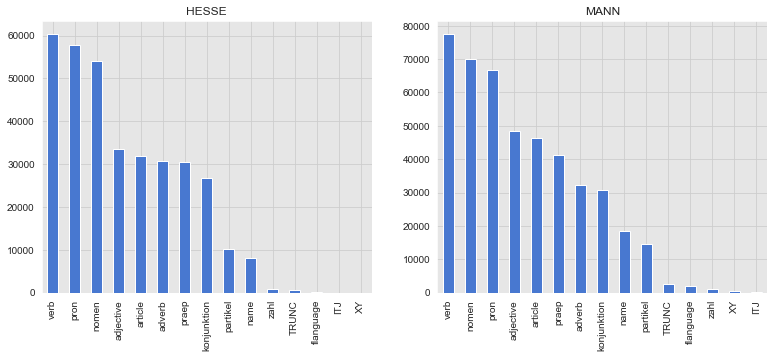

```python
f, ax = plt.subplots(1,2, figsize=(13,5))

plt.subplot(121)
hesse_tag_df.tag_agg.value_counts().plot(kind='bar')
plt.title('HESSE')

plt.subplot(122)
mann_tag_df.tag_agg.value_counts().plot(kind='bar')
plt.title('MANN')
```

```python
(mann_tag_df.tag_agg.replace({'flanguage':'other',
                              'ITJ':'other',
                              'XY':'other',
                              'TRUNC':'other',
                              'zahl':'other'
                              }) \
    .value_counts()/mann_tag_df.shape[0]) \
    .to_frame() \
    #.to_csv('/.../Documents/Processing/books/circular_bar/data/ratios.csv')
```

|  | tag_agg |
| --- | --- |
| verb | 0.171096 |
| nomen | 0.154153 |
| pron | 0.147297 |
| adjective | 0.106976 |
| article | 0.102205 |
| praep | 0.091057 |
| adverb | 0.071390 |
| konjunktion | 0.067979 |
| name | 0.041048 |
| partikel | 0.032501 |
| other | 0.014298 |

```python
hesse_tag_df.tag_agg.unique()
```

```
array(['article', 'adjective', 'nomen', 'praep', 'adverb', 'zahl', 'verb',
       'pron', 'konjunktion', 'partikel', 'name', 'TRUNC', 'flanguage',
       'ITJ', 'XY'], dtype=object)
```

```python
for typ in hesse_tag_df.tag_agg.unique():
    print((hesse_tag_df.groupby(['tag_agg','tags']) \
           .words.count().sort_values(ascending=False)/ \
        hesse_tag_df.loc[hesse_tag_df.tag_agg == typ].words.count()) \
        .loc[(typ)]) \
        #.to_csv(f'/.../Documents/Processing/books/circular_bar/data/{typ}.csv')
```

```
tags
ART    1.0
Name: words, dtype: float64
tags
ADJA    0.559561
ADJD    0.440439
Name: words, dtype: float64
tags
NN    1.0
Name: words, dtype: float64
tags
APPR       0.849595
APPRART    0.146240
APZR       0.003968
APPO       0.000197
Name: words, dtype: float64
tags
ADV    1.0
Name: words, dtype: float64
tags
CARD    1.0
Name: words, dtype: float64
tags
VVFIN    0.417341
VAFIN    0.233236
VVINF    0.133353
VVPP     0.113820
VMFIN    0.061495
VAINF    0.017199
VAPP     0.015246
VVIZU    0.003940
VMINF    0.002814
VVIMP    0.001473
VMPP     0.000083
Name: words, dtype: float64
tags
PPER      0.532108
PPOSAT    0.120949
PIAT      0.083888
PIS       0.068711
```

[output cut: 24 more lines]

```
tags
NE    1.0
Name: words, dtype: float64
tags
TRUNC    1.0
Name: words, dtype: float64
tags
FM    1.0
Name: words, dtype: float64
tags
ITJ    1.0
Name: words, dtype: float64
tags
XY    1.0
Name: words, dtype: float64
```

```python
for typ in mann_tag_df.tag_agg.unique():
    print((mann_tag_df.groupby(['tag_agg','tags']) \
           .words.count().sort_values(ascending=False)/ \
        mann_tag_df.loc[mann_tag_df.tag_agg == typ].words.count()) \
        .loc[(typ)]) \
        #.to_csv(f'/.../Documents/Processing/books/circular_bar/data/{typ}.csv')
```

[output not shown]

```python
vocab_tagged = hesse_tag_df.groupby('words').tag_agg.first().to_dict()
most_nouns  = hesse_tag_df.words \
                 .loc[hesse_tag_df.tag_agg == 'nomen'] \
                 .value_counts()
```

```python
adj_cloud = []
for idx in range(hesse_tag_df.shape[0]):
    if hesse_tag_df.words.iloc[idx] == 'Leben' or \
        hesse_tag_df.words.iloc[idx] == 'Lebens':
        for window in range(2):
            fore = hesse_tag_df.iloc[idx+window+1].words
            hind = hesse_tag_df.iloc[idx-(window+1)].words
            #if vocab_tagged[fore] == 'adjective':
            #    print(fore)
            if vocab_tagged[hind] == 'adjective':
                adj_cloud.append(hind)
```

```python
pd.Series(adj_cloud).value_counts()[:10]
```

```
ganzes      10
neues        6
ganze        6
neuen        5
eigenen      4
ganzen       3
tätigen      3
erhöhtes     3
eigenes      3
späteren     2
dtype: int64
```

```python
print('MANN Year mentions:')
for i in range(len(mann_book_list)):
    print(re.findall('(.{30}(Jahr [\d]+|Jahr. [\d]+|Jahr.. [\d]+).{30})', mann_book_list[i]))
print('\n')
print('HESSE Year mentions:')
for i in range(len(book_list)):
    print(re.findall('(.{30}(Jahr [\d]+|Jahr. [\d]+|Jahr.. [\d]+).{30})', book_list[i]))
```

[output not shown]

### Pareto vocab

```python
ratios = (hesse_tag_df \
    .words \
    .value_counts()[:500]/ \
    hesse_tag_df.shape[0]) \

cumsum = ratios.cumsum().to_frame(name='cumsum')

pd.concat([ratios,cumsum],axis=1) \
    #.to_csv('/.../Documents/Processing/books/pareto/data/ratios.csv')
```

|  | words | cumsum |
| --- | --- | --- |
| und | 0.049534 | 0.049534 |
| die | 0.017523 | 0.067057 |
| der | 0.017396 | 0.084453 |
| ich | 0.014890 | 0.099343 |
| er | 0.014456 | 0.113799 |
| ... | ... | ... |
| Nicht | 0.000225 | 0.646713 |
| worden | 0.000225 | 0.646939 |
| empfand | 0.000225 | 0.647164 |
| Tisch | 0.000225 | 0.647390 |
| schwer | 0.000223 | 0.647612 |

500 rows × 2 columns

```python
cumsum.iloc[100]
```

```
cumsum    0.456555
Name: sei, dtype: float64
```

```python
ratios = (mann_tag_df \
    .words \
    .value_counts()[:500]/ \
    mann_tag_df.shape[0]) \

cumsum = ratios.cumsum().to_frame(name='cumsum')

pd.concat([ratios,cumsum],axis=1) \
    #.to_csv('/.../Documents/Processing/books/pareto/data/ratiosMann.csv')
```

|  | words | cumsum |
| --- | --- | --- |
| und | 0.039359 | 0.039359 |
| die | 0.022319 | 0.061677 |
| der | 0.020113 | 0.081790 |
| in | 0.013751 | 0.095541 |
| zu | 0.013484 | 0.109026 |
| ... | ... | ... |
| hie | 0.000221 | 0.605830 |
| Himmel | 0.000218 | 0.606049 |
| u | 0.000218 | 0.606267 |
| Oh | 0.000218 | 0.606486 |
| große | 0.000218 | 0.606704 |

500 rows × 2 columns

```python
most_words = mann_tag_df.words \
                 .loc[mann_tag_df.tag_agg == 'nomen'] \
                 .value_counts()[:10].index.tolist()

with open('/.../Desktop/mann.txt','w') as handle:
    handle.write(', '.join(most_words))
```

#### Längstes Wort

```python
length = hesse_tag_df.assign(length = hesse_tag_df.words.apply(lambda x: len(x)))
length.loc[length.length == length.length.max()]
```

|  | words | tags | book | tag_agg | length |
| --- | --- | --- | --- | --- | --- |
| 40830 | Himmelsternkreuzteufelsludernoch | ADV | nachbarn | adverb | 32 |

```python
length = mann_tag_df.assign(length = mann_tag_df.words.apply(lambda x: len(x)))
length.loc[length.length == length.length.max()].words.values
```

```
array(['achtundsechzigtausendsiebenhundertundfünfundfünfzig'],
      dtype=object)
```

### Word Embeddings

=> Amount of words is too low.

```python
import numpy as np

def loadEmbeddingModel(File):
    print("Loading Glove Model")
    f = open(File,'r')
    gloveModel = {}
    for i,line in enumerate(f):
        splitLines = line.split()
        word = eval(splitLines[0]).decode('utf-8')
        wordEmbedding = np.array([float(value) for value in splitLines[1:]])
        gloveModel[word] = wordEmbedding
        if i%100000==0: print(f'Progress #: {i}')
    print(len(gloveModel)," words loaded!")
    return gloveModel
```

```python
%%time
vecs = loadEmbeddingModel('/.../Desktop/vectors.txt')
```

```python
vecs = pd.DataFrame(vecs).T
```

```python
##Func to turn word vec into the closest word.
import heapq
from sklearn.metrics.pairwise import cosine_similarity
def most_similar(v, N=10):
    sims = vecs.values.dot(v)
    #sims = cosine_similarity(vecs.values, vecs.loc[w].values.reshape(1,-1))
    sims = heapq.nlargest(N, zip(sims,vecs.index.values))

    return sims
```

```python
most_similar(vecs.loc['positiv'])
```

```python
vecs.loc['angenehm'].dot(vecs.loc['gut']), vecs.loc['angenehm'].dot(vecs.loc['schlecht']
```

## Fasttext sentiment tracking

```python
import fasttext
```

```python
#Memory instensive!
model = fasttext.load_model('/.../Downloads/cc.de.300.bin')
```

```python
words = []
for book in book_list:
    for w in string_to_wordlist(book):
        words.append(w)

words = set(words)
```

```python
embeddingMat = {}
for w in words:
    embeddingMat[w] = model[w]
del(model) #Save memory after embedding mat has been filled.
```

```python
%%time
#Check for every word in book, if it is closed to "good" of "bad" word vector, to
#get the positive or negative connotation of the word as the difference between
#the two vectors. Naive appoach, but worth a try.
sentiments=[]
siddharta = book_list[-1] #Look at Siddharta from Hesse because I know the book well.
gut = embeddingMat['gut'].reshape(1,-1)
schlecht = embeddingMat['schlimm'].reshape(1,-1)

for w in string_to_wordlist(siddharta):
    sim_gut, sim_schlecht = cosine_similarity(embeddingMat[w].reshape(1,-1), gut),\
                            cosine_similarity(embeddingMat[w].reshape(1,-1), schlecht)
    diff = sim_gut-sim_schlecht
    sentiments.append(diff)
```

```
CPU times: user 23.1 s, sys: 236 ms, total: 23.3 s
Wall time: 24.3 s
```

```python
sentimentsFastt=pd.Series([value[0][0] for value in sentiments]) #Flatten list of lists.
```

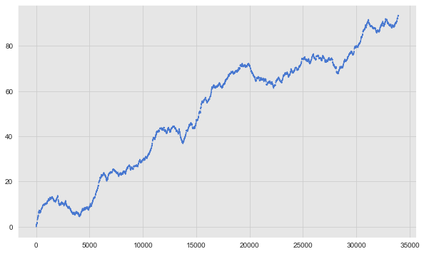

```python
#Plot cumsum to check sentiment progress.
f,ax = plt.subplots()
_=plt.plot(sentimentsFastt.cumsum(),"--")
```

Cumsum is too linear to plot sentiment progress. Try rolling window like with POS tags.

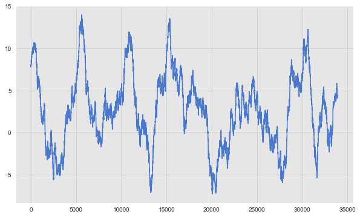

```python
sentimentsFastt.rolling(1000, min_periods=100, center=True) \
    .sum().plot(kind='line')
```

The sentiment cumsum is rising linearly and doesnt show a significant change chapterwise. No statement about the general sentiment about parts of a book can be made this way. The rolling window shows beautiful ups and downs that might correspond to the book's actual sentiment.

### External sentiments for words downloaded from:

R. Remus, U. Quasthoff & G. Heyer: SentiWS - a Publicly Available German-language Resource for Sentiment Analysis. In: Proceedings of the 7th International Language Ressources and Evaluation (LREC'10), 2010

```python
import re

pos = pd.read_csv('/.../Downloads/archive/SentiWS_v1.8c_Positive.txt',
            sep='\t',
            header=None,
            names=['word','sentiment','flexed'])
neg = pd.read_csv('/.../Downloads/archive/SentiWS_v1.8c_Negative.txt',
            sep='\t',
            header=None,
            names=['word','sentiment','flexed'])

voc = pos.append(neg)
voc.reset_index(drop=True,inplace=True)
```

```python
def wordfinder(string):
    return re.search('\w+(?=|)', string)[0]
```

```python
def remover(l):
    if '' in l: l.remove('')
    return l
```

```python
voc.word = voc.word.apply(lambda x: [wordfinder(x)])
voc.flexed = voc.flexed.fillna('').apply(lambda x: x.split(','))
voc = sents.assign(merged=voc.flexed+voc.word)
voc.merged = voc.merged.apply(remover)
```

```python
sentMap = {}
for key, value in (voc.drop(['word','flexed'],axis=1).values.tolist()):
    for string in value:
        sentMap.setdefault(string.lower())
        sentMap[string]=key
```

```python
mapKeys = set(sentMap.keys())
sentiments = [sentMap[w] if w in mapKeys else 0 for w in string_to_wordlist(siddharta)]
```

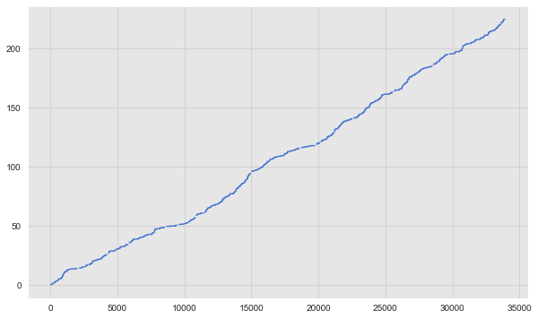

```python
f,ax = plt.subplots()
_=plt.plot(pd.Series(sentiments).cumsum(), "--")
```

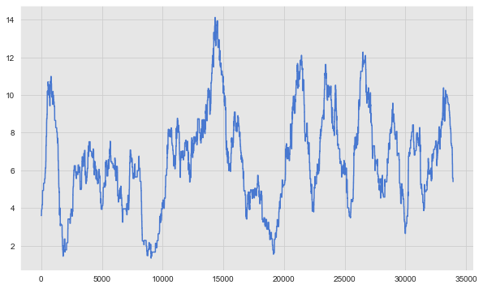

```python
pd.Series(sentiments).rolling(1000, min_periods=100, center=True).sum().plot(kind='line')
```

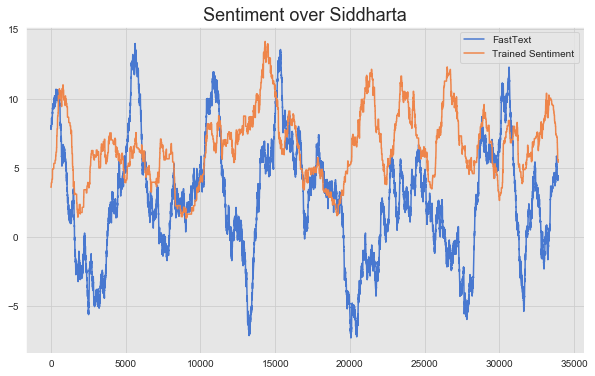

```python
f,ax=plt.subplots()
sentimentsFastt.rolling(1000, min_periods=100, center=True) \
    .sum().plot(kind='line',c=sns_c[0],label='FastText')

pd.Series(sentiments).rolling(1000, min_periods=100, center=True) \
    .sum().plot(kind='line',c=sns_c[1],label='Trained Sentiment')
plt.legend()
_=plt.title('Sentiment over Siddharta',fontsize=18)
```

The 2 different methods to assign sentiment to words in a book both produce plots of sentiment progress, that are promising. Both methods have overlapping areas when superiposed, but also areas of discrepancy. Let's check if the sentiment is realistic, by seeing where the chapter start. Since I know the book well, I will be able to manually verify the validity of the sentiment accuracy.

#### Include chapter information to manually check validity of sentiment progress

```python
#Chapter headlines
re.findall('[A-ZÄÖÜß]{2,}',siddharta)
```

```
['BEI',
 'DEN',
 'SAMANAS',
 'GOTAMA',
 'ERWACHEN',
 'ZWEITER',
 'TEIL',
 'KAMALA',
 'BEI',
 'DEN',
 'KINDERMENSCHEN',
 'SANSARA',
 'AM',
 'FLUSSE',
 'OM',
 'DER',
 'FÄHRMANN',
 'DER',
 'SOHN',
 'OM',
 'GOVINDA']
```

```python
#Find chapter headline indices to mark position of chapter starts in sentiment
#plots.
chapters = []
for headl in re.findall('[A-ZÄÖÜß]{2,}',siddharta):
    try:
        chapters.append((headl,siddharta.split().index(headl)))
    except ValueError:
        pass
```

```python
chapters = list(map(chapters.__getitem__, [0,3,4,6,9,10,11,14,17,18,19]))
```

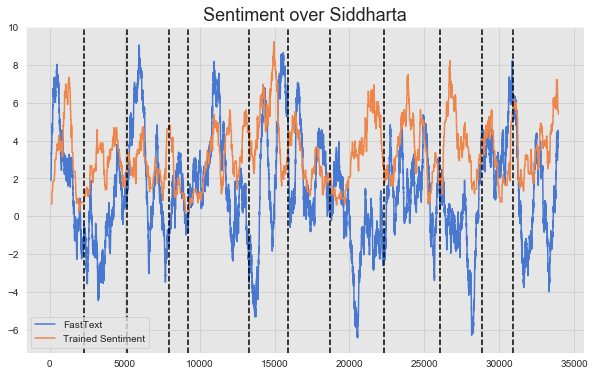

```python
f,ax=plt.subplots()
sentimentsFastt.rolling(500, min_periods=100) \
    .sum().plot(kind='line',c=sns_c[0],label='FastText')
pd.Series(sentiments).rolling(500, min_periods=100) \
    .sum().plot(kind='line',c=sns_c[1],label='Trained Sentiment')
for ch in list(zip(*chapters))[1]: ax.axvline(x=ch, ls='--', c='black')
plt.legend()
_=plt.title('Sentiment over Siddharta',fontsize=18)
```

Sohn, Samanas, Gotama,Erwachen,Kamala, Kinderm,sansara,fluss,fähr,sohn,om, Govina <-- chapters

Trained sentiment vectors seem to follow the story more closely.

```python
def sentiment_to_csv(path, book):
    sentiments = [sentMap[w] if w in mapKeys else 0 \
                  for w in string_to_wordlist(book)]
    roll = pd.Series(sentiments).rolling(500, min_periods=100).sum()
    roll.to_csv(path)
```

```python
#Write sentiment to disk for Processing3.
p = '/.../Desktop'
sentiment_to_csv(p+'/siddh.csv',book_list[-1])
sentiment_to_csv(p+'/fried.csv',mann_book_list[-1])
```

```python
list(zip(*chapters))[1]
```

```
(2305, 5187, 7931, 9253, 13304, 15914, 18685, 22299, 26041, 28860, 30912)
```